# Machine Learning in R: mlr

J.P. Meagher

29 November 2017

The package `mlr` provides an easy to use toolbox for executing machine learning projects in R.

I was introduced to this package over the summer while working as an intern at the Turing Institute. Using the tools presented here I was able to perform a study assessing the prediction power of a suite of models, in various validation settings, over the course of a few days.

Here I will work through the `mlr` tutorial available at [mlr-org](https://mlr-org.github.io/mlr-tutorial/devel/html/) and hopefully give a flavour of how straightforward Machine Learning can be in R.

# Quick Start

The mlr workflow to train, make predictions, and evaluate a learner / model on a classification problem is detailed below.

The dataset used in this demonstration is the `iris` dataset.

```r
library(mlr)
library(mlbench)
library(ggplot2)
data(iris)
head(iris)
```

```
##   Sepal.Length Sepal.Width Petal.Length Petal.Width Species
## 1          5.1         3.5          1.4         0.2  setosa
## 2          4.9         3.0          1.4         0.2  setosa
## 3          4.7         3.2          1.3         0.2  setosa
## 4          4.6         3.1          1.5         0.2  setosa
## 5          5.0         3.6          1.4         0.2  setosa
## 6          5.4         3.9          1.7         0.4  setosa
```

The first step in the workflow is to define the task. Tis involves specifying the type of analysis (classification), providing data (iris dataset) and identifying the response variable (Species).

```r
task <-  makeClassifTask(data = iris, target = "Species")
```

Next, define the learner / model to be used. That is to say, choose a specific class of predictive model (Linear Discriminant Analysis).

```r
lrn <-  makeLearner("classif.lda")
```

Define a train / test split of the data.

```r
n <-  nrow(iris)
train.set <-  sample(n, size = 2/3*n)
test.set <-  setdiff(1:n, train.set)
```

Then fit the learner / model to the training dataset.

```r
model <-  train(lrn, task, subset = train.set)
```

After training the model, make predictions for the response variable for the observations in the testing dataset.

```r
pred <-  predict(model, task = task, subset = test.set)
```

The performance of the model can be assessed by comparing the predicted and actual values of the response variable.

```r
performance(pred, measures = list(mmce, acc))
```

```
## mmce  acc
## 0.06 0.94
```

# Basics

## Learning Tasks

Learning tasks can be thought of as a high level description of the problem. The learning task defines the type of task required (regression, classification, etc.), the dataset being investigated, and the target variable when performing supervised learning tasks.

### Task types and creation

The following tasks can be set up in mlr

- RegrTask for regression problems,
- ClassifTask for binary and multi-class classification problems (cost-sensitive classification with class-dependent costs can be handled as well),
- SurvTask for survival analysis,
- ClusterTask for cluster analysis,
- MultilabelTask for multilabel classification problems,
- CostSensTask for general cost-sensitive classification (with example-specific costs).

Tasks are created by calling `make<TaskType>` (e.g. `makeClassifTask`). Details on task creation can be found in the help files called by entering `?makeClassifTask` however there are some points to note.

- All tasks require an identifier (argument `id`) and a data.frame (argument `data`). If no ID is provided it is automatically generated using the variable name of the data. The ID will be later used to name results, for example of benchmark experiments, and to annotate plots.
- The argument `target` identifies the response variable in supervised learning problems.
- The argument `blocking` is a factor of identifying the blocking level of the observations. Observations with the same blocking level ‘belong together’ and are either put all in the training or the test set during a resampling iteration.
- Once a task has been created, a full description of the task can be accessed by the command `getTaskDesc()`, and various elements of this description can be accessed individually, for example the task id can be accessed by `getTaskId()`. It is also possible to extract data from a task by `getTaskData()`.
- It is possible to modify an existing task, which may be more convenient than constructing a brand new one from scratch. For example to `dropFeatures` or `normaliseFeatures`.

To illustrate the use of learning tasks I will set up both regression and classification examples.

#### Regression

A regression task can be set up for the `BostonHousing` dataset where the response variable is the median value of owner occupied homes.

```r
data(BostonHousing, package = "mlbench")
# ?BostonHousing
regr.task <-  makeRegrTask(id = "bh", data = BostonHousing, target = "medv")
regr.task
```

```
## Supervised task: bh
## Type: regr
## Target: medv
## Observations: 506
## Features:
## numerics  factors  ordered
##       12        1        0
## Missings: FALSE
## Has weights: FALSE
## Has blocking: FALSE
```

#### Classification

In a classification problem the target / response variable must be a factor.

Here we have a dataset for which the classification task is to separate out benign and malignant breast cancers. The individual ID variable hast to be stripped out of this analysis to prefent models fitting to it.

```r
data(BreastCancer, package = "mlbench")
# ?BreastCancer
df <-  BreastCancer
df$Id <-  NULL
classif.task <-  makeClassifTask(id = "BreastCancer", data = df, target = "Class")
classif.task
```

```
## Supervised task: BreastCancer
## Type: classif
## Target: Class
## Observations: 699
## Features:
## numerics  factors  ordered
##        0        4        5
## Missings: TRUE
## Has weights: FALSE
## Has blocking: FALSE
## Classes: 2
##    benign malignant
##       458       241
## Positive class: benign
```

## Learners

Learners in `mlr` provide a unified interface to all popular machine learning methods in R. Many are already integrated in mlr, others are not, but the package is specifically designed to make extensions simple.

### Constructing a learner

To construct a learner in `mlr` call `makeLearner`. Within the constructor you specify the method to be used, control hyperparameters, control the output of predictions (probabilities or response for classification), and set an ID to name the object.

```r
#?makeLearner
## Classification tree, set it up for predicting probabilities
classif.lrn <- makeLearner("classif.randomForest", predict.type = "prob", fix.factors.prediction = TRUE)
classif.lrn
```

```
## Learner classif.randomForest from package randomForest
## Type: classif
## Name: Random Forest; Short name: rf
## Class: classif.randomForest
## Properties: twoclass,multiclass,numerics,factors,ordered,prob,class.weights,oobpreds,featimp
## Predict-Type: prob
## Hyperparameters:
```

```r
## Regression gradient boosting machine, specify hyperparameters via a list
regr.lrn <- makeLearner("regr.gbm", par.vals = list(n.trees = 500, interaction.depth = 3))
regr.lrn
```

```
## Learner regr.gbm from package gbm
## Type: regr
## Name: Gradient Boosting Machine; Short name: gbm
## Class: regr.gbm
## Properties: missings,numerics,factors,weights,featimp
## Predict-Type: response
## Hyperparameters: distribution=gaussian,keep.data=FALSE,n.trees=500,interaction.depth=3
```

Similarly to tasks, aspects of the learner can be accesed such as `getLearnerType()` and learners can be modified without creating a new learner from scratch by commands such as `setHyperPars()`.

It is also possible to list available learners.

```r
lrns <-  listLearners()
```

A list of the most popular learners available in mlr is given [here](https://www.r-bloggers.com/most-popular-learners-in-mlr/).

## Training a Learner

Training a learner is nothing more than fitting a model (given by the Learner) to a given dataset (defined by the task). ti is done by applying the `train` function to a perticular learner and a suitable Task.

The function `train` returns an object of class `WrappedModel`, which encapsulates the fitted model, i.e., the output of the underlying R learning method. Additionally, it contains some information about the Learner, the Task, the features and observations used for training, and the training time. A WrappedModel can subsequently be used to make a prediction for new observations.

The fitted model in slot `$learner.model` of the `WrappedModel` object can be accessed using function `getLearnerModel`.

By default, the whole data set in the Task is used for training. The `subset` argument of train takes a logical or integer vector that indicates which observations to use, for example if you want to split your data into a training and a test set or if you want to fit separate models to different subgroups in the data. However, all standard resampling strategies are supported. Therefore you usually do not have to subset the data yourself.

```r
## Get the number of observations
n = getTaskSize(bh.task)

## Use 1/3 of the observations for training
train.set = sample(n, size = n/3)

## Train the learner
mod = train("regr.lm", bh.task, subset = train.set)
mod
```

```
## Model for learner.id=regr.lm; learner.class=regr.lm
## Trained on: task.id = BostonHousing-example; obs = 168; features = 13
## Hyperparameters:
```

As a final point, you can specify observation `weights` that reflect the relevance of observations in the training process. For example in the BreastCancer data set class `benign` is almost twice as frequent as class malignant. In order to grant both classes equal importance in training the classifier we can weight the examples according to the inverse class frequencies in the data set as shown in the following R code.

```r
## Calculate the observation weights
target = getTaskTargets(bc.task)
tab = as.numeric(table(target))
w = 1/tab[target]

train("classif.rpart", task = bc.task, weights = w)
```

```
## Model for learner.id=classif.rpart; learner.class=classif.rpart
## Trained on: task.id = BreastCancer-example; obs = 683; features = 9
## Hyperparameters: xval=0
```

## Predicting Outcomes for New Data

Simply call `predict` on the object returned by `train` and pass the data you want to make predictions for. There are two ways to pass the data:

- either pass the task via the `task` argument, or
- pass a data.frame via the `newdata` argument.

The predict function also has a `subset` argument for setting aside training and testing portions of the data in a task.

```r
n <-  getTaskSize(bh.task)
train.set <-  seq(1, n, by = 2)
test.set <-  seq(2, n, by = 2)
lrn <-  makeLearner("regr.gbm", n.trees = 100)
mod <-  train(lrn, bh.task, subset = train.set)

task.pred <-  predict(mod, task = bh.task, subset = test.set)
task.pred
```

```
## Prediction: 253 observations
## predict.type: response
## threshold:
## time: 0.00
##    id truth response
## 2   2  21.6 22.29351
## 4   4  33.4 23.18377
## 6   6  28.7 22.40064
## 8   8  27.1 22.12375
## 10 10  18.9 22.12375
## 12 12  18.9 22.12375
## ... (253 rows, 3 cols)
```

```r
n <-  nrow(iris)
iris.train <-  iris[seq(1, n, by = 2), -5]
iris.test <-  iris[seq(2, n, by = 2), -5]
task <-  makeClusterTask(data = iris.train)
mod <-  train("cluster.kmeans", task)

newdata.pred <-  predict(mod, newdata = iris.test)
newdata.pred
```

```
## Prediction: 75 observations
## predict.type: response
## threshold:
## time: 0.00
##    response
## 2         1
## 4         1
## 6         1
## 8         1
## 10        1
## 12        1
## ... (75 rows, 1 cols)
```

Once the predictions have been made and the predict object stored then there are commands for accessing various aspects of the object, depending on the underlying model / learner being implemented.

For regression tasks standardised errors can be extracted, in classification tasks prediction probabilities and confusion matrices are accessible, and the decision threshold can be adjusted.

There are also functions which allow the user to plot predictions for particular models witl a single line of code.

[figure not shown]

Decision Tree prediction of the species in the iris dataset. xval is the number of cross validation groups and mmce is the mean misclassification error.

```r
lrn <-  makeLearner("classif.rpart", id = "CART")
plotLearnerPrediction(lrn, task = iris.task)
```

## Performance

The quality of predictions made by a model can be evaluated by calling `performance` on the object produced by `predict`. `mlr` provides measures for all types of learning tasks and these can be explored by `?measures` or

```r
listMeasures('regr')
```

```
##  [1] "rsq"         "rae"         "rmsle"       "mse"         "rrse"
##  [6] "medse"       "mae"         "timeboth"    "timepredict" "medae"
## [11] "featperc"    "mape"        "rmse"        "kendalltau"  "sse"
## [16] "arsq"        "expvar"      "msle"        "sae"         "timetrain"
## [21] "spearmanrho"
```

```r
listMeasures(bh.task)
```

```
##  [1] "rsq"         "rae"         "rmsle"       "mse"         "rrse"
##  [6] "medse"       "mae"         "timeboth"    "timepredict" "medae"
## [11] "featperc"    "mape"        "rmse"        "kendalltau"  "sse"
## [16] "arsq"        "expvar"      "msle"        "sae"         "timetrain"
## [21] "spearmanrho"
```

Calculating a performance measure is straightforward

```r
n <-  getTaskSize(bh.task)
lrn <-  makeLearner("regr.gbm", n.trees = 1000)
mod <-  train(lrn, task = bh.task, subset = seq(1, n, 2))
pred <-  predict(mod, task = bh.task, subset = seq(2, n, 2))

performance(pred, measures = list(mse, rmse, mae))
```

```
##       mse      rmse       mae
## 42.945557  6.553286  4.554991
```

That covers the workflow outlined in the Quick Start section.

# Resampling

Resampling strategies such as Cross Validation or Bootstrapping are often used to assess model performance. `mlr` provides a straightforward approach to resampling via the function `makeResampleDesc` and supports

- Cross Validation (`"CV"`)
- Leave-one-out cross-validation (`"LOO"`)
- Repeated cross-validation (`"RepCV"`)
- Out-of-bag bootstrap (`"Bootstrap"`)
- Subsampling (`"Subsample"`)
- Holdout (training/test) (`"Holdout"`).

The resampling strategy can then be implemented for a particular task.

```r
rdesc <- makeResampleDesc("CV", iters = 3)
r <- resample("regr.lm", bh.task, rdesc)
r
```

```
## Resample Result
## Task: BostonHousing-example
## Learner: regr.lm
## Aggr perf: mse.test.mean=25.3
## Runtime: 0.0369999
```

Similarly,

```r
rdesc <-  makeResampleDesc("Subsample", iters = 5, split = 4/5)

lrn <-  makeLearner("classif.rpart", parms = list(split = "information"))

r <-  resample(lrn, sonar.task, rdesc, measures = list(mmce, fpr, fnr, timetrain))
r
```

```
## Resample Result
## Task: Sonar-example
## Learner: classif.rpart
## Aggr perf: mmce.test.mean=0.233,fpr.test.mean=0.242,fnr.test.mean=0.238,timetrain.test.mean=0.018
## Runtime: 0.126
```

```r
addRRMeasure(r, list(ber, timepredict))
```

```
## Resample Result
## Task: Sonar-example
## Learner: classif.rpart
## Aggr perf: mmce.test.mean=0.233,fpr.test.mean=0.242,fnr.test.mean=0.238,timetrain.test.mean=0.018,ber.test.mean=0.24,timepredict.test.mean=0.004
## Runtime: 0.126
```

When performing a resampling, one can save the models fitted to each training set if desired, simply set the argument `models = T`. This can be memory intensive however and if there is specific information required this can be instead accessed by the `extract` argument. a function passed to extract will take only the information needed in the mode and store it in the extract slot.

A final note on Resampling is that Stratification and blocking are straightforward.

Stratification with respect to a categorical variable ensures that all its values are present in each training and test set in approximately the same proportions as it is present in the original dataset. This is set up by `stratify = T` or `stratify.cols = 'col.name'` in `makeResampledesc`.

Blocking is required when there are subsets of the data that ‘belong together’ in some sense meaning that for each train test data pair a block is either entirely in the training or the test dataset. This is set up when creating the task.

# Benchmark Experiments

Running a benchmarking experiment involves applying one or more models / learnenrs to one or more datasets and then comparing performance. `mlr` makes such experiments relatively straightforward, reducing the experiment to calling the function `benchmark` on a list of learners and a list of tasks. `benchmark` essentially implements a resampling for each combination of learner and task and the performance on each combination can be compared over one or more performance measures.

A small benchmarking study comparing linear discriminant analysis and a classification tree applied to the sonar dataset is performed below.

```r
lrns <-  list(makeLearner("classif.lda"), makeLearner("classif.rpart"))

rdesc <-  makeResampleDesc("Holdout")

bmr <-  benchmark(lrns, sonar.task, rdesc)

bmr
```

```
##         task.id    learner.id mmce.test.mean
## 1 Sonar-example   classif.lda      0.3000000
## 2 Sonar-example classif.rpart      0.2714286
```

## Memory Constraints

The object produced by `benchmark` contains a lot of information including predictions for each learner / task combination (diabled by `keep.pred = F`) and the full models (disabled by `models = F`), which can be discarded if memory constraints become an issue.

## Reproducible Results

Benchmarking experiments can be made reproducible by setting the random seed at the beginning of the experiment.

## Extending / Merging Experiments

```r
lrns2 <-  list(makeLearner("classif.randomForest"), makeLearner("classif.glmnet"))
bmr2 <-  benchmark(lrns2, sonar.task, rdesc, show.info = FALSE)

mergeBenchmarkResults(list(bmr, bmr2))
```

```
##         task.id           learner.id mmce.test.mean
## 1 Sonar-example          classif.lda      0.3000000
## 2 Sonar-example        classif.rpart      0.2714286
## 3 Sonar-example classif.randomForest      0.2285714
## 4 Sonar-example       classif.glmnet      0.2428571
```

We should be wary of extending benchmarking experiments in this manner however as they will not necessarily have been performed on the same test / training split. To manage this when extending / merging benchmark experiments instead

```r
rin <-  getBMRPredictions(bmr)[[1]][[1]]$instance

bmr3 <-  benchmark(lrns2, sonar.task, rin, show.info = FALSE)

mergeBenchmarkResults(list(bmr, bmr3))
```

```
##         task.id           learner.id mmce.test.mean
## 1 Sonar-example          classif.lda      0.3000000
## 2 Sonar-example        classif.rpart      0.2714286
## 3 Sonar-example classif.randomForest      0.1285714
## 4 Sonar-example       classif.glmnet      0.2714286
```

## Analysis and Visualisation

Finally, consider an example benchmarking study comparing 3 classification models / learners applied to 5 separate datasets / tasks. To assess performance we consider the mean misclassification error (mmce), balanced error rate (ber), and the training time (timetrain)

```r
lrns = list(
  makeLearner("classif.lda", id = "lda"),
  makeLearner("classif.rpart", id = "rpart"),
  makeLearner("classif.randomForest", id = "randomForest")
)

ring.task = convertMLBenchObjToTask("mlbench.ringnorm", n = 600)
wave.task = convertMLBenchObjToTask("mlbench.waveform", n = 600)

tasks = list(iris.task, sonar.task, pid.task, ring.task, wave.task)
rdesc = makeResampleDesc("CV", iters = 10)
meas = list(mmce, ber, timetrain)
bmr = benchmark(lrns, tasks, rdesc, meas, show.info = FALSE)
bmr
```

```
##                        task.id   learner.id mmce.test.mean ber.test.mean
## 1                 iris-example          lda     0.02000000    0.01888889
## 2                 iris-example        rpart     0.06666667    0.07059524
## 3                 iris-example randomForest     0.04000000    0.04777778
## 4             mlbench.ringnorm          lda     0.36000000    0.36051868
## 5             mlbench.ringnorm        rpart     0.17666667    0.17630484
## 6             mlbench.ringnorm randomForest     0.06000000    0.05919209
## 7             mlbench.waveform          lda     0.16833333    0.16512580
## 8             mlbench.waveform        rpart     0.28166667    0.27809259
## 9             mlbench.waveform randomForest     0.17000000    0.16885949
## 10 PimaIndiansDiabetes-example          lda     0.23051948    0.27598365
## 11 PimaIndiansDiabetes-example        rpart     0.26946343    0.31590012
## 12 PimaIndiansDiabetes-example randomForest     0.23685919    0.27590286
## 13               Sonar-example          lda     0.24547619    0.25864719
## 14               Sonar-example        rpart     0.28880952    0.28066891
```

[output cut: 17 more lines]

It would be useful to visualise these results somehow and as seen earier `mlr` can interface with `ggplot2` to do just that.

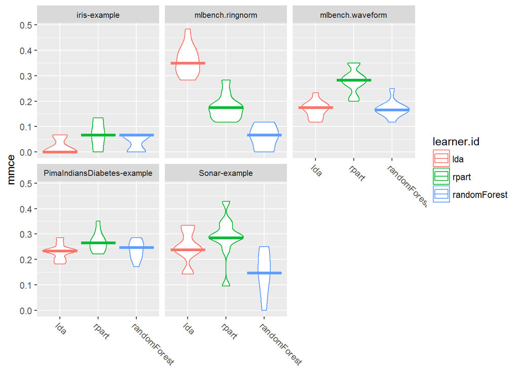

```r
plotBMRBoxplots(bmr, measure = mmce, style = "violin", pretty.names = FALSE) +
  aes(color = learner.id) +
  theme(strip.text.x = element_text(size = 8))
```

# Closing Remarks

Hopefully this has convinced you that `mlr` is an incredibly powerful tool for implementing machine learning in R. This only covers the most basic of introductions to the package and those interested are directed to [mlr-org](https://mlr-org.github.io/mlr-tutorial/devel/html/) for a more comprehensive and up-to-date overview of the package.